# Measles Across the Globe

Author

Natalie Cartwright, Zita Tam, Aryan Nair, Amanda Dong

# Introduction

News of measles outbreaks are constantly being released. Despite vaccines, measles continues to affect the whole world. The World Health Organization collects data on monthly measles and rubella cases across the world. We will be focusing on measles cases, as it’s typically more severe and contagious compared to rubella. We were provided with data on suspected measles cases, confirmed cases, and total cases. The World Health Organization provides these counts for each country, and by two time frames: monthly and yearly (2012 to 2025). All data is provisional and is reported by a country’s WHO member each year.

In addition to our measles data, we will also be using data collected from API Ninja on Air Quality for each country. The website does not explicitly say where they collected the Air Quality data from. We were provided with data on several major pollutants, but will focus on the overall Air Quality Index (AQI). The Air Quality Index is a globally used measurement that ranges from 0 to 500, with higher values meaning worse air pollution The index is calculated based on the 5 major air pollutants. All information on air quality provided are the latest known data.

```r
library(httr)
library(tidyjson)
library(jsonlite)
library(tidyverse)
library(stringr)
library(gt)
library(paletteer)
library(ggridges)

cases_month <- readr::read_csv('https://raw.githubusercontent.com/rfordatascience/tidytuesday/main/data/2025/2025-06-24/cases_month.csv')
cases_year <- readr::read_csv('https://raw.githubusercontent.com/rfordatascience/tidytuesday/main/data/2025/2025-06-24/cases_year.csv')
meta_df <- read_csv("https://raw.githubusercontent.com/amandaadong/project1/main/metadf.csv")
```

# Research Question 1: Has the total number of reported measles cases increased or decreased over time globally?

## Background

To answer this question, we first needed to determine how each country’s total number of measles cases was changing year-by-year. To do this, we compared each sequential year and categorized the change as declining (if the previous year had more cases), surging (if the previous year had less cases), and stable (if cases stayed relatively the same).

## Data Summaries

```r
trend_label <- function(current, previous) {
  pct_change <- (current - previous) / previous * 100
  case_when(
    pct_change < -20 ~ "declining",
    pct_change >  20 ~ "surging",
    .default = "stable"
  )
}

yearly_summary <- cases_year |>
  group_by(year) |>
  summarise(
    total_cases = sum(measles_total, na.rm = TRUE),
    n_countries = n_distinct(country),
    .groups = "drop"
  ) |>
  arrange(year) |>
  mutate(
    prev_total = lag(total_cases),
    pct_change = round((total_cases - prev_total) / prev_total * 100, 1),
    trend = trend_label(total_cases, prev_total)
  ) |>
  select(year, total_cases, n_countries, pct_change, trend)
```

### Table 1: Global Measles Cases by Year

```r
yearly_summary |>
  select(year, total_cases, n_countries, pct_change, trend) |>
  gt() |>
  cols_label(
    year = md("**Year**"),
    total_cases = md("**Total Cases**"),
    n_countries = md("**Countries Reporting**"),
    pct_change = md("**% Change from Prior Year**"),
    trend = md("**Trend**")
  ) |>
  fmt_number(columns = total_cases, use_seps = TRUE, decimals = 0) |>
  fmt_number(columns = n_countries, use_seps = TRUE, decimals = 0) |>
  fmt_number(columns = pct_change, decimals = 1, suffix = "%") |>
  data_color(
    columns = pct_change,
    fn = scales::col_numeric(
      palette = c("#D9565C", "#FFFFFF", "#647D4B"),
      domain  = c(-100, 200)
    )
  ) |>
  tab_style(
    style = cell_text(color = "#D9565C", weight = "bold"),
    locations = cells_body(columns = trend, rows = trend == "declining")
  ) |>
  tab_style(
    style = cell_text(color = "#647D4B", weight = "bold"),
    locations = cells_body(columns = trend, rows = trend == "surging")
  ) |>
  tab_style(
    style = cell_text(color = "#848C80"),
    locations = cells_body(columns = trend, rows = trend == "stable")
  ) |>
  tab_spanner(
    label = md("**Case Counts**"),
    columns = c(total_cases, n_countries)
  ) |>
  tab_spanner(
    label = md("**Year-over-Year Change**"),
    columns = c(pct_change, trend)
  ) |>
  tab_style(
    style = cell_text(weight = "bold"),
    locations = cells_column_spanners()
  ) |>
  tab_options(
    table.width = pct(100),
    column_labels.font.weight = "bold",
    heading.align = "left",
    table.border.top.color = "black",
    row.striping.include_table_body = TRUE
  ) |>
  sub_missing(missing_text = "—")
```

Table 1: Global Measles Cases by Year (2012–2025)

| **Year** | **Case Counts** **Total Cases** | **Case Counts** **Countries Reporting** | **Year-over-Year Change** **% Change from Prior Year** | **Year-over-Year Change** **Trend** |
| --- | --- | --- | --- | --- |
| 2012 | 112,548 | 150 | — | stable |
| 2013 | 178,526 | 148 | 58.6 | surging |
| 2014 | 290,888 | 154 | 62.9 | surging |
| 2015 | 247,474 | 176 | −14.9 | stable |
| 2016 | 180,015 | 179 | −27.3 | declining |
| 2017 | 168,190 | 182 | −6.6 | stable |
| 2018 | 276,157 | 182 | 64.2 | surging |
| 2019 | 541,401 | 187 | 96.0 | surging |
| 2020 | 93,840 | 175 | −82.7 | declining |
| 2021 | 59,619 | 153 | −36.5 | declining |
| 2022 | 174,340 | 168 | 192.4 | surging |
| 2023 | 321,889 | 176 | 84.6 | surging |
| 2024 | 359,534 | 184 | 11.7 | stable |
| 2025 | 88,853 | 168 | −75.3 | declining |

Global measles cases fluctuated during the 2012-2025 period. There was a high peak in 2019 before declining and significantly changing 192.4% in 2022. The decline of measles cases in 2020-2021 could be due to the increase in COVID-19 cases, but more data is needed to understand if COVID-19 was a direct cause.

### Figure 1: Percent Change Year-to-Year

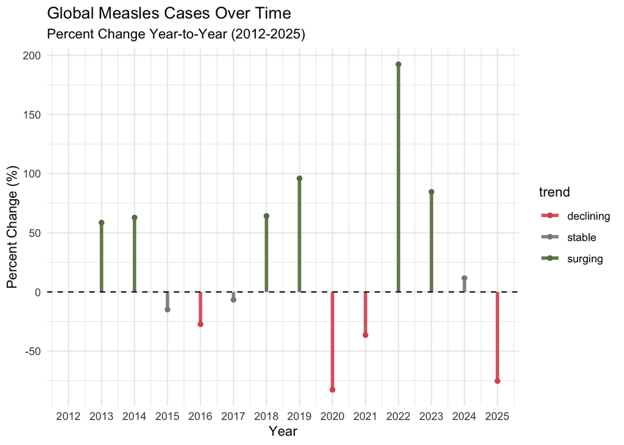

Figure 1: Percent Change in measles cases

```r
ggplot(yearly_summary, aes(x = year, xend = year, y = 0, yend = pct_change,
                           color = trend)) +
  geom_segment(size = 1.3, alpha = 0.9) +
  geom_point(aes(y = pct_change)) +
  theme_minimal() +
  theme(panel.border = element_blank()) +
  scale_x_continuous(breaks = yearly_summary$year) +
  scale_y_continuous(breaks = seq(-100, 200, by = 50)) +
  geom_hline(yintercept = 0, linetype = "dashed") +
    labs(title = "Global Measles Cases Over Time", subtitle = "Percent Change Year-to-Year (2012-2025)") +
  xlab("Year") + ylab("Percent Change (%)") +
  scale_color_manual(values = c(surging = "#647D4BFF",
                      declining = "#D9565CFF",
                      stable = "#848C80"))
```

Not only were we interested in looking at how measles cases changed over time, but we also wanted to know if there has been a change in the methods of finding measles over time. The number of total measles cases for each country, month, and year is made up of 3 possible methods of detecting measles: Clinically-compatible, Epidemiologically-linked, and Laboratory-confirmed. Let’s see if the proportion of each method has changed throughout the years.

```r
methods <- list(clin_prop = "clinical",
                epi_prop = "epi",
                lab_prop = "lab")

cases_filtered <- cases_year %>% filter(!is.na(measles_clinical),
                                     !is.na(measles_total),
                                     !is.na(measles_epi_linked),
                                     !is.na(measles_lab_confirmed))
yearly_totals <- cases_filtered %>% group_by(year) %>%
  summarise(
    total = sum(measles_total),
    clinical = sum(measles_clinical),
    epi = sum(measles_epi_linked),
    lab = sum(measles_lab_confirmed),
    .groups = "drop")

props <- function(col) {
  yearly_totals[[col]] / yearly_totals$total
}

propsbyyear <- bind_cols(
  select(yearly_totals, year),
  map_dfc(methods, props)
)

plot_long <- propsbyyear %>%
  pivot_longer(cols = c(clin_prop, epi_prop, lab_prop),
               names_to = "method",
               values_to = "proportion")
```

### Table 2: Detection Method Proportions

```r
propsbyyear |>
  gt() |>
  cols_label(
    year = md("**Year**"),
    clin_prop = md("**Clinical**"),
    epi_prop = md("**Epi-Linked**"),
    lab_prop = md("**Lab Confirmed**")
  ) |>
  fmt_percent(columns = c(clin_prop, epi_prop, lab_prop), decimals = 1) |>
  tab_spanner(
    label = md("**Proportion of Total Cases by Detection Method**"),
    columns = c(clin_prop, epi_prop, lab_prop)
  ) |>
  tab_style(
    style = cell_text(weight = "bold"),
    locations = cells_column_spanners()
  ) |>
  tab_options(
    table.width = pct(100),
    column_labels.font.weight = "bold",
    heading.align = "left",
    table.border.top.color = "black",
    row.striping.include_table_body = TRUE
  )
```

Table 2: Proportion of Measles Cases by Detection Method (2012–2025)

| **Year** | **Proportion of Total Cases by Detection Method** **Clinical** | **Proportion of Total Cases by Detection Method** **Epi-Linked** | **Proportion of Total Cases by Detection Method** **Lab Confirmed** |
| --- | --- | --- | --- |
| 2012 | 34.9% | 23.4% | 41.7% |
| 2013 | 22.4% | 34.9% | 42.7% |
| 2014 | 42.5% | 22.6% | 34.9% |
| 2015 | 50.9% | 20.5% | 28.5% |
| 2016 | 55.4% | 18.9% | 25.6% |
| 2017 | 55.3% | 18.6% | 26.1% |
| 2018 | 46.3% | 21.1% | 32.6% |
| 2019 | 27.2% | 51.0% | 21.8% |
| 2020 | 32.6% | 28.1% | 39.3% |
| 2021 | 46.6% | 11.1% | 42.3% |
| 2022 | 38.5% | 31.0% | 30.5% |
| 2023 | 28.3% | 27.1% | 44.6% |
| 2024 | 29.5% | 23.9% | 46.7% |
| 2025 | 32.1% | 18.3% | 49.6% |

### Figure 2: Detection Method by Year

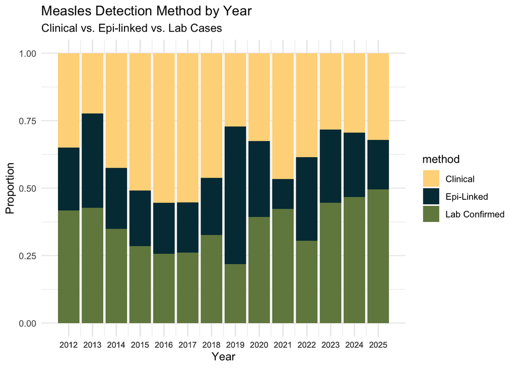

Figure 2: Method of Finding Measles Year-by-Year

```r
ggplot(plot_long, aes(x = year, y = proportion, fill = method)) +
  geom_bar(position = "fill", stat = "identity") +
  scale_x_continuous(breaks = plot_long$year) +
  theme_minimal() +
  theme(axis.text.x = element_text(size = 8)) +
  labs(title = "Measles Detection Method by Year",
       subtitle = "Clinical vs. Epi-linked vs. Lab Cases") +
  xlab("Year") +
  ylab("Proportion") +
  scale_fill_paletteer_d("nationalparkcolors::Acadia",
                         labels = c(clin_prop = "Clinical",
                                 epi_prop = "Epi-Linked",
                                 lab_prop = "Lab Confirmed"))
```

# Research Question 2: Is there an association between a country’s air quality and number of measles cases?

## Background

To answer this question, we first need to examine the relationship between a country’s Air Quality Index (AQI) and its measles burden. To do this, we average each country’s suspected measles cases across all available years and applied a log10 transformation to account for the highly skewed distribution of case counts. Plotting the log10 transformed average annual cases by AQI allows us to visually assess whether any linear trend exists between air pollution levels and measles burden before formalizing the relationship through a regression model.

```r
meta_df |>
  select(iso3, country, year, gdp_per_capita_nominal,
         measles_incidence_rate_per_1000000_total_population,
         measles_lab_confirmed, measles_total) |>
  glimpse()
```

```
Rows: 2,396
Columns: 7
$ iso3                                                <chr> "DZA", "DZA", "DZA…
$ country                                             <chr> "Algeria", "Algeri…
$ year                                                <dbl> 2012, 2013, 2014, …
$ gdp_per_capita_nominal                              <dbl> 6057.974, 5997.896…
$ measles_incidence_rate_per_1000000_total_population <dbl> 1.46, 0.00, 0.00, …
$ measles_lab_confirmed                               <dbl> 2, 0, 0, 2, 21, 74…
$ measles_total                                       <dbl> 55, 0, 0, 62, 49, …
```

### Table 3: AQI vs. Average Measles Cases

```r
summary_vars <- c("total_aqi", "measles_total", "measles_incidence_rate_per_1000000_total_population")

filtered_df <- meta_df %>%
  filter(!is.na(total_aqi), !is.na(measles_total),
         !is.na(measles_incidence_rate_per_1000000_total_population))

country_summary <- summary_vars %>%
  map(~ filtered_df %>%
        group_by(country) %>%
        summarise(!!.x := mean(.data[[.x]], na.rm = TRUE), .groups = "drop")
  ) %>%
  reduce(left_join, by = "country") %>%
  mutate(aqi_category = case_when(
    total_aqi <= 50  ~ "Good",
    total_aqi <= 100 ~ "Moderate",
    total_aqi <= 150 ~ "Unhealthy for Sensitive Groups",
    total_aqi >  150 ~ "Unhealthy"
  )) %>%
  arrange(desc(total_aqi))

country_summary %>%
  gt() %>%
  cols_label(
    country      = "Country",
    total_aqi    = "Mean AQI",
    aqi_category = "AQI Category",
    measles_total = "Mean Annual Cases",
    measles_incidence_rate_per_1000000_total_population = "Incidence Rate (per 1,000,000)"
  ) %>%
  fmt_number(columns = total_aqi, decimals = 1) %>%
  fmt_number(columns = measles_total, decimals = 1) %>%
  fmt_number(columns = measles_incidence_rate_per_1000000_total_population, decimals = 2) %>%
  tab_spanner(
    label   = "Air Quality",
    columns = c(total_aqi, aqi_category)
  ) %>%
  tab_spanner(
    label   = "Measles Burden",
    columns = c(measles_total, measles_incidence_rate_per_1000000_total_population)
  ) %>%
  tab_header(
    title    = "Air Quality and Measles Burden by Country",
    subtitle = "166 countries ordered by mean AQI (highest to lowest)"
  ) %>%
  data_color(
    columns = total_aqi,
    palette = c("lightgreen", "lightblue", "dodgerblue", "blue"),
    domain  = c(0, 200)
  ) %>%
  tab_style(
    style     = cell_text(weight = "bold"),
    locations = cells_column_spanners()
  ) %>%
  tab_footnote(
    footnote  = "Mean values calculated across all available years per country.",
    locations = cells_column_labels(columns = c(measles_total,
                                                measles_incidence_rate_per_1000000_total_population))
  )
```

Table 3: Air Quality and Measles Burden by Country

Air Quality and Measles Burden by Country

166 countries ordered by mean AQI (highest to lowest)

| Country | Air Quality Mean AQI | Air Quality AQI Category | Measles Burden Mean Annual Cases<sup>1</sup> | Measles Burden Incidence Rate (per 1,000,000)<sup>1</sup> |
| --- | --- | --- | --- | --- |
| Portugal | 200.0 | Unhealthy | 20.3 | 2.12 |
| United States of America | 200.0 | Unhealthy | 383.3 | 1.56 |
| Cyprus | 199.0 | Unhealthy | 6.3 | 5.87 |
| Denmark | 195.0 | Unhealthy | 8.2 | 1.44 |
| Lebanon | 184.0 | Unhealthy | 338.3 | 58.03 |
| Canada | 182.0 | Unhealthy | 288.8 | 14.38 |
| Democratic People's Republic of Korea | 178.0 | Unhealthy | 0.6 | 0.02 |
| Japan | 169.0 | Unhealthy | 179.8 | 1.50 |
| Bosnia and Herzegovina | 166.0 | Unhealthy | 594.2 | 174.39 |
| Albania | 160.0 | Unhealthy | 144.9 | 50.68 |
| Italy | 160.0 | Unhealthy | 1,253.9 | 21.23 |
| Uzbekistan | 160.0 | Unhealthy | 692.4 | 21.61 |
| Nepal | 156.0 | Unhealthy | 287.6 | 10.41 |
| Sudan | 156.0 | Unhealthy | 2,675.0 | 66.09 |
| Montenegro | 154.0 | Unhealthy | 20.5 | 35.14 |
| United Kingdom of Great Britain and Northern Ireland | 154.0 | Unhealthy | 742.4 | 11.70 |
| Azerbaijan | 151.0 | Unhealthy | 2,208.9 | 214.11 |
| Greece | 151.0 | Unhealthy | 280.0 | 26.12 |
| Kyrgyzstan | 151.0 | Unhealthy | 3,577.4 | 619.84 |
| France | 147.0 | Unhealthy for Sensitive Groups | 666.1 | 10.96 |
| Guinea | 147.0 | Unhealthy for Sensitive Groups | 409.4 | 34.04 |
| Ireland | 145.0 | Unhealthy for Sensitive Groups | 50.0 | 10.84 |
| Libya | 141.0 | Unhealthy for Sensitive Groups | 178.1 | 26.90 |
| Norway | 141.0 | Unhealthy for Sensitive Groups | 6.1 | 1.18 |
| United Arab Emirates | 141.0 | Unhealthy for Sensitive Groups | 227.4 | 25.22 |
| Russian Federation | 140.0 | Unhealthy for Sensitive Groups | 3,868.1 | 28.02 |
| Mongolia | 137.0 | Unhealthy for Sensitive Groups | 3,553.2 | 1,188.58 |
| Bolivia (Plurinational State of) | 136.0 | Unhealthy for Sensitive Groups | 0.5 | 0.05 |
| Chad | 135.0 | Unhealthy for Sensitive Groups | 810.6 | 48.92 |
| Jordan | 134.0 | Unhealthy for Sensitive Groups | 25.8 | 2.65 |

[output cut: 136 more lines]

<sup>1</sup> Mean values calculated across all available years per country.

### Table 4: Measles Burden by AQI Quartile

```r
summarise_by_quartile <- function(df, var, n_tiles = 4) {

  quartile_labels <- c("Q1 (Lowest AQI)", "Q2", "Q3", "Q4 (Highest AQI)")

  df %>%
    filter(!is.na({{ var }}), !is.na(measles_total), !is.na(measles_incidence_rate_per_1000000_total_population)) %>%
    mutate(
      quartile = ntile({{ var }}, n_tiles),
      quartile = factor(quartile, labels = quartile_labels)
    ) %>%
    group_by(quartile) %>%
    summarise(
      n_countries    = n_distinct(country),
      mean_aqi       = mean({{ var }},       na.rm = TRUE),
      total_cases    = sum(measles_total,    na.rm = TRUE),
      mean_incidence = mean(measles_incidence_rate_per_1000000_total_population,       na.rm = TRUE),
      .groups = "drop"
    )
}

# call the function
quartile_summary <- summarise_by_quartile(meta_df, total_aqi)

quartile_summary %>%
  gt() %>%
  cols_label(
    quartile       = "AQI Quartile",
    n_countries    = "No. Countries",
    mean_aqi       = "Mean AQI",
    total_cases    = "Total Cases",
    mean_incidence = "Mean Incidence Rate"
  ) %>%
  fmt_number(columns = c(mean_aqi, mean_incidence), decimals = 2) %>%
  fmt_number(columns = total_cases, decimals = 0) %>%
  tab_header(
    title    = "Measles Burden Across AQI Quartiles",
    subtitle = "Does measles burden increase with worsening air quality?"
  ) %>%
  data_color(columns = mean_aqi, palette = c("lightblue", "dodgerblue", "blue"))
```

Table 4: Measles Burden by AQI Quartile

Measles Burden Across AQI Quartiles

Does measles burden increase with worsening air quality?

| AQI Quartile | No. Countries | Mean AQI | Total Cases | Mean Incidence Rate |
| --- | --- | --- | --- | --- |
| Q1 (Lowest AQI) | 39 | 13.03 | 959,010 | 62.06 |
| Q2 | 45 | 39.69 | 574,436 | 35.11 |
| Q3 | 44 | 79.14 | 1,173,118 | 24.94 |
| Q4 (Highest AQI) | 41 | 148.99 | 521,665 | 87.56 |

## Figure 3: Linear Regression between Air Quality Index and log10 transformed Average Measles Cases by Country

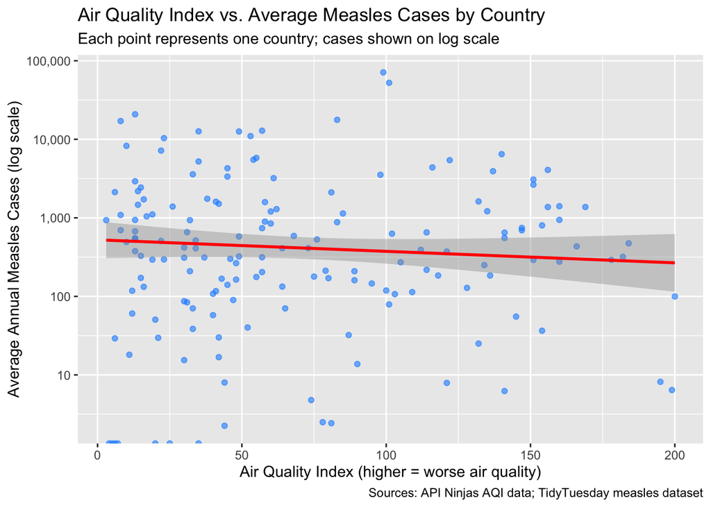

Figure 3: Linear Regression between Air Quality Index and log10 transformed Average Measles Cases by Country

```r
meta_df %>%
  filter(!is.na(total_aqi), !is.na(total_suspected_measles_rubella_cases)) %>%
  group_by(country, total_aqi) %>%
  summarise(avg_cases = mean(total_suspected_measles_rubella_cases, na.rm = TRUE)) %>%
  ggplot(aes(x = total_aqi, y = avg_cases)) +
  geom_point(alpha = 0.6, color = "dodgerblue") +
  geom_smooth(method = "lm", se = TRUE, color = "red") +
  scale_y_log10(labels = scales::comma) +
  labs(
    title = "Air Quality Index vs. Average Measles Cases by Country",
    subtitle = "Each point represents one country; cases shown on log scale",
    x = "Air Quality Index (higher = worse air quality)",
    y = "Average Annual Measles Cases (log scale)",
    caption = "Sources: API Ninjas AQI data; TidyTuesday measles dataset"
  )
```

The scatterplot shows a slight negative linear association between AQI and average measles cases. Observing the spread of the points,countries with low AQI show a wider vertical spread of average measles cases than countries with higher quality index. The fanning pattern could indicate that there is heteroscedasticity and could a formal test could be done to determine if there is an association.

## Model

### Table 4: Linear Regression Coefficients

```r
aqi_model <- meta_df |>
  filter(!is.na(total_aqi), !is.na(total_suspected_measles_rubella_cases)) |>
  group_by(country, total_aqi) |>
  summarise(avg_cases = mean(total_suspected_measles_rubella_cases, na.rm = TRUE),
            .groups = "drop") |>
  mutate(log_avg_cases = log10(avg_cases + 1))

model <- lm(log_avg_cases ~ total_aqi, data = aqi_model)

wide_model <- broom::tidy(model, conf.int = TRUE) %>%
  mutate(
    term = recode(term,
      "(Intercept)" = "Intercept",
      "total_aqi" = "Air Quality Index"
    ), conf_int = str_c("(", round(conf.low, 3), ", ", round(conf.high, 3), ")")
  ) %>%
  select(term, estimate, std.error, statistic, p.value, conf_int) %>%
  rename(c(Term = term, Estimate = estimate, SE = std.error, Statistic = statistic,
           "P-value" = p.value, "Conf. Interval" = conf_int))

wide_model |>
  gt() |>
  fmt_number(columns = -"Conf. Interval", decimals = 3) |>
  tab_style(style = cell_text(weight = "bold"),
                              locations = cells_column_labels()) |>
  tab_style(style = cell_text(weight = "bold"),
            locations = cells_body(
              columns = Term,
              rows = Term %in% c("Intercept", "Air Quality Index")
            )) |>
  tab_caption(caption = "Table 4. Linear Regression coefficients for the association between measles cases and AQI.")
```

Table 4: Linear Regression coefficients for the association between measles cases and AQI

| Term | Estimate | SE | Statistic | P-value | Conf. Interval |
| --- | --- | --- | --- | --- | --- |
| Intercept | 2.448 | 0.130 | 18.864 | 0.000 | (2.192, 2.704) |
| Air Quality Index | 0.001 | 0.001 | 0.603 | 0.547 | (-0.002, 0.004) |

### Figure 4: Measles Distribution by AQI Quartile

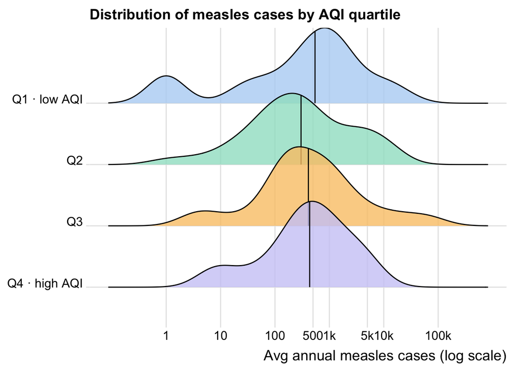

```r
aqi_model |>
  mutate(
    aqi_quartile = ntile(total_aqi, 4),
    aqi_label = case_when(
      aqi_quartile == 1 ~ "Q1 · low AQI",
      aqi_quartile == 2 ~ "Q2",
      aqi_quartile == 3 ~ "Q3",
      aqi_quartile == 4 ~ "Q4 · high AQI"
    ) |> factor(levels = c("Q4 · high AQI","Q3","Q2","Q1 · low AQI"))
  ) |>
  ggplot(aes(x = log_avg_cases, y = aqi_label, fill = aqi_label)) +
  geom_density_ridges(
    scale = 1.4,
    alpha = 0.8,
    quantile_lines = TRUE,
    quantiles = 2        # draws the median line
  ) +
  scale_x_continuous(
  breaks = log10(c(1, 10, 100, 500, 1000, 5000, 10000, 100000)),
  labels = c("1", "10", "100", "500", "1k", "5k", "10k", "100k")
  ) +
  scale_fill_manual(values = c("#CECBF6","#FAC775","#9FE1CB","#B5D4F4")) +
  labs(
    title = "Distribution of measles cases by AQI quartile",
    x = "Avg annual measles cases (log scale)",
    y = NULL
  ) +
  theme_ridges() +
  theme(legend.position = "none")
```

Countries with low AQI (Q1) and countries with high AQI (Q4) have around a median 500 of measles cases. This finding is consistent with the linear regression model having a weak association. Countries with low AQI have a bimodal distribution, indicating that they are not a homogeneous group. From this observation, there may be a divide between high-income and well-vaccinated countries and low income countries that also have low AQI, but a weaker healthcare system.